# **Intro Chemistry I**

## **Concept Check and/or Class Practice**

- Which of the following describes an Arrhenius acid and base? (a) An acid is a substance that produces a hydroxide ion and a base is a substance that produces hydrogen ions in water. (b) An acid is a substance that donates a hydrogen ion to another substance and a base is a substance that accepts a hydroxide ion from another substance. (c) An acid is a substance that produces hydrogen ions in water and a base is a substance that produces hydroxide ions in water. (d) An acid is a substance that donates a hydrogen ion to another substance and a base is a substance that accepts a hydrogen ion from another substance.
- Which of the following describes a Bronsted–Lowry acid and base? (a) An acid is a substance that produces a hydroxide ion and a base is a substance that produces hydrogen ions in water. (b) An acid is a substance that donates a hydrogen ion to another substance and a base is a substance that accepts a hydroxide ion from another substance. (c) An acid is a substance that produces hydrogen ions in water and a base is a substance that produces hydroxide ions in water. (d) An acid is a substance that donates a hydrogen ion to another substance and a base is a substance that accepts a hydrogen ion from another substance.
- how you differentiate acid and base by (a) the chemical structure (b) the property
- Identify a conjugate acid–base pair in the following equation.  
  HF(aq) + H<sub>2</sub>O(l) <----> H<sub>3</sub>0<sup>+</sup>(aq) + F<sup>-</sup>(aq)  
  (a) HF(aq) and H<sub>3</sub>0<sub>+</sub>(aq) (b) HF(aq) and F<sup>-</sup>(aq) (c) H<sub>2</sub>O(l) and F<sup>-</sup>(aq) (d) HF(aq) and H<sub>2</sub>O(l)
- which of the following is conjugate base, if H2O is base:  
  HCl(aq) + H<sub>2</sub>O(l) ---> H<sub>3</sub>O<sup>+</sup>(aq) + Cl<sup>-</sup>(aq)  
  (a) HCl (b) H<sub>2</sub>O (c) H<sub>3</sub>O<sup>+</sup> (d) Cl<sup>-</sup> (e) none
- What are the differences between a monoprotic, diprotic, and triprotic acid? (a) A monoprotic acid supplies one proton per molecule; a diprotic acid supplies two protons per molecule; and a triprotic acid supplies three protons per molecule. (b) A monoprotic acid supplies one proton per molecule; a diprotic acid supplies two or more protons per molecule; and a triprotic acid supplies three protons per molecule. (c) A monoprotic acid supplies one hydroxide ion per molecule; a diprotic acid supplies two hydroxide ions per molecule; and a triprotic acid supplies three hydroxide ions per molecule. (d) These three acids differ by the degree of ionization when placed in a nonpolar solvent.
- how you differentiate strong acid and weak acid by the concept of ionization?
- Which of the following weak acid? (a) HCl(aq) (b) H<sub>2</sub>SO<sub>4</sub>(aq) (c) CH<sub>3</sub>COOH(aq) (d) HNO<sub>3</sub> (aq)
- Which of the following equations would be a correct representation of a strong acid when placed in water?

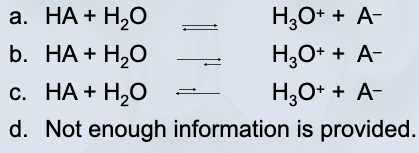

- How does a chemist define a salt? (a) White granular substance used as a food seasoning. (b) White granular substance that can cause high blood pressure when consumed in large quantities. (c) Ionic compound containing a metal or polyatomic ion as the positive ion and a nonmetal or polyatomic ion (except hydroxide) as the negative ion. (d) Ionic compound containing a nonmetal or polyatomic ion as the positive ion and a metal or polyatomic ion as the negative ion.
- In a neutralization reaction, what products are formed? (a) Acid and base (b) Acid and water (c) Base and water (d) Water and salt
- Calculate [H3O<sup>+</sup>] or [OH<sup>-</sup>] as required for each of the following solutions at 24°C, and state whether the solution is neutral, acidic, or basic. (a) 1.0 × 10–4 M OH<sup>-</sup> (b) 2.0 M H<sub>3</sub>O<sup>+</sup> (c) 1.0 × 10–4 M H<sub>3</sub>O<sup>+</sup> (d) 0.040 M OH<sup>-</sup>
- The pH of a solution is 5.85. What is the concentration of H3O+ for this solution?
- An acidic solution is defined as (a) An aqueous solution in which the concentration of H3O+ ion is lower than that of OH– ion. (b) An aqueous solution in which the concentration of H3O+ ion is equal to that of OH– ion. (c) An aqueous solution in which the concentration of H3O+ ion is higher than that of OH– ion. (d) An aqueous solution in which the concentration of OH– ion is higher than that of H3O+ ion.
- What two active species are contained in a buffer? (a) A substance that resists changes in pH when a small amount of base is added (b) A substance that resists changes in pH when a small amount of acid is added (c) A weak acid and its conjugate base (d) All of these
- What is an electrolyte? (a) A substance that completely dissociates or ionizes when placed in water (b) A substance that incompletely dissociates or ionizes when placed in water (c) A substance whose aqueous solution conducts electricity (d) All of these
- The concentration of Ca<sup>2+</sup> ion present in a sample is 5.3 mEq/L. How many milligrams of Ca<sup>2+</sup> ion are present in 180.0 mL of the sample?
- pH of 0.1 M solution of H<sub>2</sub>SO<sub>4</sub> ? (a) between 0 to 1  
  (b) 1  
  (c) between 1 to 2  
  (d) 2  
  (e) none of these
- As the [H<sup>+</sup>] decreases in the aqueous solution. (a) [OH<sup>-</sup>] increase  
  (b) pH increase  
  (c) solution becomes less acidic  
  (d) both B and C
- Complete and balance following acid-base reaction.  
  KOH(aq) + H<sub>3</sub>PO<sub>4</sub>(aq) →
- When determining the concentration of an acid or base, a(n) _____ is performed using a(n) _____ to visualize the desired pH of the solution. (a) acid–base indicator; acid base titration (b) acid–base titration; acid–base indicator (c) acid titration; base indicator (d) base titration; acid indicator
- define pH scale and buffers solution?
- Why do most buffer solutions contain two dissolved components?
- Which of the following pairs of substances could act as a buffer? (a) strong acid, HNO<sub>3</sub> + week acid CH<sub>3</sub>COOH  
  (b) strong acid HNO<sub>3</sub> + strong salt NaNO<sub>3</sub>  
  (c) strong acid, HNO<sub>3</sub> + week salt, CH<sub>3</sub>COONa  
  (d) week acid, CH<sub>3</sub>COOH + week salt, CH<sub>3</sub>COONa  
  (e) strong acid, HNO<sub>3</sub> + strong base, NaOH.
- 25 mL of acid requires 14.8 mL of 0.351 M base for complete neutralization. What is the molarity of the acid and what two products are formed after neutralization? (a) 0.208 M; a salt and water (b) 4.81 M; a salt and water (c) 0.208 M; not enough information is provided to determine the products. (d) 4.81 M; not enough information is provided to determine the products.
- For the titration of sulfuric acid (H<sub>2</sub>SO<sub>4</sub>) with sodium hydroxide (NaOH), how many moles of sodium hydroxide would be required to react with 1.00 L of 0.500 M sulfuric acid to reach the endpoint?
- What is the molarity of an HCl solution if 22.5 mL of a 0.100 M NaOH solution are needed to titrate a 25.0 mL sample of the acid?

### [**Cengage Chapter 10 electronic online h.w. on Canvas topics**:](https://bridgeport.instructure.com/courses/2177365/assignments/21601004)

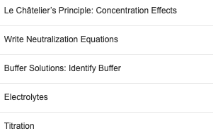